# Ejercicio dimensionalidad intrínseca

*Aprendizaje máquina II*

*Curso 2023-2024*

Authors:

- Rubén Castillo Carrasco

- Manuel Rubio Martínez

Utilizaremos la librería scikit-dimension - Intrinsic dimension estimation in Python. https://scikit-dimension.readthedocs.io/en/latest/index.html

```python
import skdim
import numpy as np
import pandas as pd
import plotly.graph_objects as go
from plotly.subplots import make_subplots
```

# Generamos datasets

Se generan dos conjuntos de datos que contienen clusters con diferentes dimensiones intrínsecas (ID).

```python
#generate data
data1, clusters = skdim.datasets.lineDiskBall(n = 2000, random_state = 0)
data2 = skdim.datasets.swissRoll3Sph(n_swiss=4000,n_sphere=2000, h=2, random_state = 0)

#plot
fig = make_subplots(rows=1, cols=2,specs=[[{'type': 'Scatter3d'}]*2])

trace1=go.Scatter3d(dict(zip(['x','y','z'],data1.T[:3])),
       mode='markers',marker=dict(size=1.5,colorbar=dict()))
trace2=go.Scatter3d(dict(zip(['x','y','z'],data2.T[:3])),
       mode='markers',marker=dict(size=1.5,colorbar=dict()))

fig.add_traces([trace1,trace2],rows=1,cols=[1,2])
fig.layout.update(height=450, width=800)
fig.show()
```

# Estimar la ID global

### Ejemplo spectral gap

```python
pca=skdim.id.lPCA(ver='maxgap')

#global ID
gid1=pca.fit(data1).dimension_
print(pca.gap_)
gid2=pca.fit(data2).dimension_
print(pca.gap_)
print(gid1,gid2)
```

```
[11.48990492  1.97873214]
[ 1.29356694  1.48651622 12.35287536]
1 3
```

```python
pca=skdim.id.lPCA(ver='FO')

#global ID
gid1=pca.fit(data1).dimension_
gid2=pca.fit(data2).dimension_
print(gid1,gid2)
```

```
2 3
```

# Estimar la ID local

Los estimadors calculan el ID local usando k-NN en cada punto, lo que es útil para encontrar si un conjunto de datos tiene regiones con diferentes ID.

```python
#local ID (pointwise estimates)
lid1=pca.fit_pw(data1,n_neighbors=25).dimension_pw_
lid2=pca.fit_pw(data2,n_neighbors=25).dimension_pw_
```

```python
fig.update_traces({'text':lid1,'marker.color':lid1,'marker.colorbar':dict(thickness=5,x=.42)},col=1)
fig.update_traces({'text':lid2,'marker.color':lid2,'marker.colorbar':dict(thickness=5,x=.98)},col=2)
fig.show()
```

# 1. Generamos conjuntos de datos del benchmark.

```python
benchmark = skdim.datasets.BenchmarkManifolds(random_state=0)
#dictionary with all datasets
dict_data = benchmark.generate()
#ground truth dataframe
truth = benchmark.truth
#generate a dataset with custom parameters
M1_sphere_custom = benchmark.generate(name="M1_Sphere",n=2500,dim=10,d=5)
M1_sphere = dict_data['M1_Sphere'] #np.array (n x dim)
truth
```

|  | Intrinsic Dimension | Number of variables | Description |
| --- | --- | --- | --- |
| M1_Sphere | 10 | 11 | 10D sphere linearly embedded |
| M2_Affine_3to5 | 3 | 5 | Affine space |
| M3_Nonlinear_4to6 | 4 | 6 | Concentrated figure, mistakable with a 3D one |
| M4_Nonlinear | 4 | 8 | Nonlinear manifold |
| M5a_Helix1d | 1 | 3 | 1D helix |
| M5b_Helix2d | 2 | 3 | 2D helix |
| M6_Nonlinear | 6 | 36 | Nonlinear manifold |
| M7_Roll | 2 | 3 | Swiss Roll |
| M8_Nonlinear | 12 | 72 | Nonlinear (highly curved) manifold |
| M9_Affine | 20 | 20 | Affine space |
| M10a_Cubic | 10 | 11 | 10D hypercube |
| M10b_Cubic | 17 | 18 | 17D hypercube |
| M10c_Cubic | 24 | 25 | 24D hypercube |
| M10d_Cubic | 70 | 71 | 70D hypercube |
| M11_Moebius | 2 | 3 | Möebius band 10-times twisted |
| M12_Norm | 20 | 20 | Isotropic multivariate Gaussian |
| M13a_Scurve | 2 | 3 | 2D S-curve |
| M13b_Spiral | 1 | 13 | 1D helix curve |
| Mbeta | 10 | 40 | Manifold generated with a smooth nonuniform pd... |
| Mn1_Nonlinear | 18 | 72 | Nonlinearly embedded manifold of high ID (see ... |
| Mn2_Nonlinear | 24 | 96 | Nonlinearly embedded manifold of high ID (see ... |
| Mp1_Paraboloid | 3 | 12 | 3D paraboloid, nonlinearly embedded in (3(3+1)... |
| Mp2_Paraboloid | 6 | 21 | 6D paraboloid, nonlinearly embedded in (3*(6+1... |
| Mp3_Paraboloid | 9 | 30 | 9D paraboloid, nonlinearly embedded in (3*(9+1... |

Para cada uno de los datasets siguientes (teniendo en cuenta los parámetros por defecto):

- M5a_Helix1d
- M5b_Helix2d
- M11_Moebius

Y los siguientes algoritmos:

- Spectral Gap
- PCA (método por defecto)
- Correlation dimension
- MADA
1. Representa los datos en 3D
2. Calcula el ID global y local con los algoritmos anteriores.
3. Construye un dataframe con el nombre del dataset, el ID estimado por cada método y el ID verdadero.
4. ¿Qué algoritmo funciona mejor en cada caso?

## M5 Helix 1d

### Representación 3D

```python
resultsM5A = {'real':[1]}

M5a_Helix1d=dict_data['M5a_Helix1d']
fig = make_subplots(rows=1, cols=1,specs=[[{'type': 'Scatter3d'}]])

trace1=go.Scatter3d(dict(zip(['x','y','z'],M5a_Helix1d.T[:3])),
       mode='markers',marker=dict(size=1.5,colorbar=dict()))

fig.add_traces([trace1],rows=1,cols=1)
fig.layout.update(height=450, width=800)
fig.show()
```

## Espectral Gap:

### ID Global

```python
pca=skdim.id.lPCA(ver='maxgap')

#global ID
gid1=pca.fit(M5a_Helix1d).dimension_
print(pca.gap_)
print(gid1)

resultsM5A['Spectral_g'] = [gid1]
```

```
[1.02863937 4.5093348 ]
2
```

### ID Local

```python
#local ID (pointwise estimates)
lid1=pca.fit_pw(M5a_Helix1d,n_neighbors=25).dimension_pw_

fig.update_traces({'text':lid1,'marker.color':lid1,'marker.colorbar':dict(thickness=5,x=.42)},col=1)

fig.show()
```

```python
elem, times = np.unique(lid1,return_counts = True)
mode = elem[np.argmax(times)]
resultsM5A['Spectral_l'] = [mode]
```

## PCA:

### ID Global

```python
pca=skdim.id.lPCA()

#global ID
gid1=pca.fit(M5a_Helix1d).dimension_
print(gid1)

resultsM5A['lPCA_g'] = [gid1]
```

```
3
```

### ID local

```python
#local ID (pointwise estimates)
lid1=pca.fit_pw(M5a_Helix1d,n_neighbors=25).dimension_pw_

fig.update_traces({'text':lid1,'marker.color':lid1,'marker.colorbar':dict(thickness=5,x=.42)},col=1)

fig.show()
```

```python
elem, times = np.unique(lid1,return_counts = True)
mode = elem[np.argmax(times)]
resultsM5A['lPCA_l'] = [mode]
```

## Correlation dimension:

### ID Global

```python
CorrInt=skdim.id.CorrInt()

#global ID
gid1=CorrInt.fit(M5a_Helix1d).dimension_
print(gid1)

resultsM5A['CorrInt_g'] = [mode]
```

```
1.0087691410953517
```

### ID Local

```python
lid1=CorrInt.fit_pw(M5a_Helix1d,n_neighbors=25).dimension_pw_

fig.update_traces({'text':lid1,'marker.color':lid1,'marker.colorbar':dict(thickness=5,x=.42)},col=1)

fig.show()
```

```python
elem, times = np.unique(lid1,return_counts = True)
mode = elem[np.argmax(times)]
resultsM5A['CorrInt_l'] = [mode]
```

## Mada:

### ID Global

```python
MADA=skdim.id.MADA()

#global ID
gid1=MADA.fit(M5a_Helix1d).dimension_
print(gid1)

resultsM5A['MADA_g'] = [gid1]
```

```
1.0844260232969454
```

### ID Local

```python
lid1=MADA.fit_transform_pw(M5a_Helix1d)

fig.update_traces({'text':lid1,'marker.color':lid1,'marker.colorbar':dict(thickness=5,x=.42)},col=1)

fig.show()
```

```python
elem, times = np.unique(lid1,return_counts = True)
mode = elem[np.argmax(times)]
resultsM5A['MADA_l'] = [mode]
```

De manera global, Mada y Correlation Dimension funcionan parecido, acercándose al valor 1 de la dimensión real, mientras que en local PCA consigue el valor exacto de 1 para todos los puntos. Una vez probados todos los modelos, se imprime los resultados del data frame

```python
data_frame = pd.DataFrame(resultsM5A)

data_frame.index = ["M5A"]

data_frame
```

|  | real | Spectral_g | Spectral_l | lPCA_g | lPCA_l | CorrInt_g | CorrInt_l | MADA_g | MADA_l |
| --- | --- | --- | --- | --- | --- | --- | --- | --- | --- |
| M5A | 1 | 2 | 2 | 3 | 1 | 1 | 0.755263 | 1.084426 | 0.42661 |

Se obtiene que, tanto MADA como Corr proporcionan los resultados acertados para el conjunto de datos dado, de dimensión 1, pero vemos como muchos de los algoritmos no saben reconocer bien la dimensión.

## M5b_Helix2d

```python
resultsM5b = {'real':[2]}

M5b_Helix2d=dict_data['M5b_Helix2d']
fig = make_subplots(rows=1, cols=1,specs=[[{'type': 'Scatter3d'}]])

trace1=go.Scatter3d(dict(zip(['x','y','z'],M5b_Helix2d.T[:3])),
       mode='markers',marker=dict(size=1.5,colorbar=dict()))

fig.add_traces([trace1],rows=1,cols=1)
fig.layout.update(height=450, width=800)
fig.show()
```

## Espectral Gap:

### ID Global

```python
pca=skdim.id.lPCA(ver='maxgap')

#global ID
gid1=pca.fit(M5b_Helix2d).dimension_
print(pca.gap_)
print(gid1)

resultsM5b['Spectral_g'] = [gid1]
```

```
[1.06053695 7.90459734]
2
```

### ID Local

```python
#local ID (pointwise estimates)
lid1=pca.fit_pw(M5b_Helix2d,n_neighbors=25).dimension_pw_

fig.update_traces({'text':lid1,'marker.color':lid1,'marker.colorbar':dict(thickness=5,x=.42)},col=1)

fig.show()
```

```python
elem, times = np.unique(lid1,return_counts = True)
mode = elem[np.argmax(times)]
resultsM5b['Spectral_l'] = [mode]
```

## PCA:

### ID Global

```python
pca=skdim.id.lPCA()

#global ID
gid1=pca.fit(M5b_Helix2d).dimension_
print(pca.gap_)
print(gid1)


pca=skdim.id.lPCA(ver='FO')

#global ID
gid1=pca.fit(M5b_Helix2d).dimension_
print(gid1)

resultsM5b['PCA_g'] =[gid1]
```

```
[1.06053695 7.90459734]
3
3
```

### ID local

```python
#local ID (pointwise estimates)
lid1=pca.fit_pw(M5b_Helix2d,n_neighbors=25).dimension_pw_

fig.update_traces({'text':lid1,'marker.color':lid1,'marker.colorbar':dict(thickness=5,x=.42)},col=1)

fig.show()
```

```python
elem, times = np.unique(lid1,return_counts = True)
mode = elem[np.argmax(times)]
resultsM5b['PCA_l'] = [mode]
```

## Correlation dimension:

### ID Global

```python
CorrInt=skdim.id.CorrInt()

#global ID
gid1=CorrInt.fit(M5b_Helix2d).dimension_
print(gid1)

resultsM5b['Corr_g'] = [gid1]
```

```
2.7947659610698903
```

### ID Local

```python
lid1=CorrInt.fit_pw(M5b_Helix2d,n_neighbors=25).dimension_pw_

fig.update_traces({'text':lid1,'marker.color':lid1,'marker.colorbar':dict(thickness=5,x=.42)},col=1)

fig.show()
```

```python
elem, times = np.unique(lid1,return_counts = True)
mode = elem[np.argmax(times)]
resultsM5b['Corr_l'] = [mode]
```

## Mada:

### ID Global

```python
MADA=skdim.id.MADA()

#global ID
gid1=MADA.fit(M5b_Helix2d).dimension_
print(gid1)

resultsM5b['Mada_l'] = [gid1]
```

```
3.16917733801504
```

### ID Local

```python
lid1=MADA.fit_transform_pw(M5b_Helix2d)

puntos=fig.update_traces({'text':lid1,'marker.color':lid1,'marker.colorbar':dict(thickness=5,x=.42)},col=1)

fig.show()
```

```python
elem, times = np.unique(lid1,return_counts = True)
mode = elem[np.argmax(times)]
resultsM5b['MADA_l'] = [mode]
```

```python
data_frame = pd.DataFrame(resultsM5b)
data_frame.index = ["M5B"]
data_frame
```

|  | real | Spectral_g | Spectral_l | PCA_g | PCA_l | Corr_g | Corr_l | Mada_l | MADA_l |
| --- | --- | --- | --- | --- | --- | --- | --- | --- | --- |
| M5B | 2 | 2 | 2 | 3 | 3 | 2.794766 | 1.159139 | 3.169177 | 0.913127 |

Vemos como en algoritmos globales, espectral gap lo hace muy bien, en cambio Mada y Correlation se confunden entre el global y el local, al haber puntos en el eje de la espiral que los detectan de mayor dimensionalidad.

## M11_Moebius

```python
resultsM11 = {'real':[2]}

M11_Moebius=dict_data['M11_Moebius']
fig = make_subplots(rows=1, cols=1,specs=[[{'type': 'Scatter3d'}]])

trace1=go.Scatter3d(dict(zip(['x','y','z'],M11_Moebius.T[:3])),
       mode='markers',marker=dict(size=1.5,colorbar=dict()))

fig.add_traces([trace1],rows=1,cols=1)
fig.layout.update(height=450, width=800)
fig.show()
```

## Spectral Gap

```python
pca=skdim.id.lPCA(ver='maxgap')

#global ID
gid1=pca.fit(M11_Moebius).dimension_
print(pca.gap_)
print(gid1)

resultsM11['Spectral_g'] = [gid1]
```

```
[ 1.01923334 12.72974693]
2
```

```python
#local ID (pointwise estimates)
lid1=pca.fit_pw(M11_Moebius,n_neighbors=25).dimension_pw_

fig.update_traces({'text':lid1,'marker.color':lid1,'marker.colorbar':dict(thickness=5,x=.42)},col=1)

fig.show()
```

```python
elem, times = np.unique(lid1,return_counts = True)
mode = elem[np.argmax(times)]
resultsM11['Spectral_l'] = [mode]
```

## PCA:

### ID Global

```python
pca=skdim.id.lPCA()

#global ID
gid1=pca.fit(M11_Moebius).dimension_
print(pca.gap_)
print(gid1)


pca=skdim.id.lPCA(ver='FO')

#global ID
gid1=pca.fit(M11_Moebius).dimension_
print(gid1)

resultsM11['PCA_g'] = [gid1]
```

```
[ 1.01923334 12.72974693]
3
3
```

### ID local

```python
#local ID (pointwise estimates)
lid1=pca.fit_pw(M11_Moebius,n_neighbors=25).dimension_pw_

fig.update_traces({'text':lid1,'marker.color':lid1,'marker.colorbar':dict(thickness=5,x=.42)},col=1)

fig.show()
```

```python
elem, times = np.unique(lid1,return_counts = True)
mode = elem[np.argmax(times)]
resultsM11['PCA_l'] = [mode]
```

## Correlation dimension

### ID Global

```python
CorrInt=skdim.id.CorrInt()

#global ID
gid1=CorrInt.fit(M11_Moebius).dimension_
print(gid1)

resultsM11['Corr_g'] = [gid1]
```

```
1.9714281226356525
```

### ID Local

```python
lid1=CorrInt.fit_pw(M11_Moebius,n_neighbors=25).dimension_pw_

fig.update_traces({'text':lid1,'marker.color':lid1,'marker.colorbar':dict(thickness=5,x=.42)},col=1)

fig.show()
```

```python
elem, times = np.unique(lid1,return_counts = True)
mode = elem[np.argmax(times)]
resultsM11['Corr_l'] = [mode]
```

## Mada

### ID Global

```python
MADA=skdim.id.MADA()

#global ID
gid1=MADA.fit(M11_Moebius).dimension_
print(gid1)

resultsM11['MADA_g'] = [gid1]
```

```
2.097531933754531
```

### ID Local

```python
lid1=MADA.fit_transform(M11_Moebius)

fig.update_traces({'text':lid1,'marker.color':lid1,'marker.colorbar':dict(thickness=5,x=.42)},col=1)

fig.show()
```

```python
elem, times = np.unique(lid1,return_counts = True)
mode = elem[np.argmax(times)]
resultsM11['MADA_l'] = [mode]
```

```python
data_frame = pd.DataFrame(resultsM11)
data_frame.index  = ["M11"]
data_frame
```

|  | real | Spectral_g | Spectral_l | PCA_g | PCA_l | Corr_g | Corr_l | MADA_g | MADA_l |
| --- | --- | --- | --- | --- | --- | --- | --- | --- | --- |
| M11 | 2 | 2 | 2 | 3 | 2 | 1.971428 | 1.189773 | 2.097532 | 2.097532 |

# 2.Obtén la dimensionalidad intrínseca del subconjunto de datos de MNIST pertenecientes al 1. ¿Qué métodos utilizarías, globales o locales? Justifica las respuestas.

Dado que MNIST es un conjunto de una gran cantidad de imágenes conformado por una gran cantidad de imágenes (instancias) de una gran dimensionalidad (cada uno de los píxeles que la conforman). Se trata de estudiar la dimensionalidad global del conjunto de datos, quitando toda aquella información redundante en los mismos producido por cambios en la forma de escritura de las letras, por lo que consideramos que, lo mas adecuado en este caso sería hacer uso de métodos globales, como `MADA` o `CorrInt` para la obtención de la dimensionalidad intrínseca de los datos. En el caso de estar conformado el conjunto de datos por subconjuntos de dimensionaliadad distinta, como podría ser el caso debido a la presencia de grupos de caligrafía distintos, los metodos locales permitirian discernir entre los mismos

```python
from sklearn.datasets import fetch_openml

# Load MNIST dataset
mnist = fetch_openml('mnist_784', version=1)

# Extract images and labels
X, y = mnist.data, mnist.target.astype(int)

# Filter images and labels corresponding to digit 1
X_1 = X[y == 1]
print(X_1.shape)
```

```
(7877, 784)
```

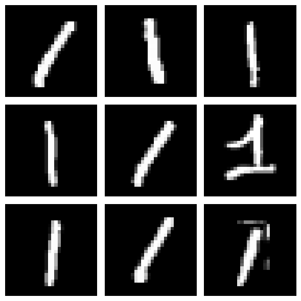

```python
import matplotlib.pyplot as plt

# Assuming X_1 is a DataFrame, reset the index
X_1.reset_index(drop=True, inplace=True)

# Define the number of samples to display
num_samples = 9

# Create a figure and axes
fig, axes = plt.subplots(3, 3, figsize=(6, 6))

# Plot each sample
for i in range(num_samples):
    # Reshape the image to its original dimensions (28x28 pixels)
    sample_image = X_1.iloc[i].values.reshape(28, 28)
    # Plot the image on the corresponding axis
    axes[i // 3, i % 3].imshow(sample_image, cmap='gray')
    axes[i // 3, i % 3].axis('off')

# Adjust layout to prevent overlap
plt.tight_layout()
# Display the plot
plt.show()
```

A pesar de considerar a priori los métodos globales para la obtención de la dimensionalidad del conjunto de datos, probaremos ambas para el estudio de los resultados en el conjunto de los datos.